# D2SC: Weekly Assignments

Vincent Espana

2024-11-08

Initial Loading

ggdist Loading

# Week 1 Assignment

To figure out how to load a library in RStudio, I used a quick Google search. I entered “how to load libraries in R” into the searched bar and opened the first two links, both of which explained to use the “library()” function. Running an additional code block using the help function certified the contents of those link. After adding it into the code block and running it, I was able to see that the library was successfully loaded into RStudio. I reset R and cleared the outputs and ran it once more to be sure.

https://bookdown.org/nana/intror/install-and-load-packages.html https://campus.datacamp.com/courses/intermediate-r/chapter-3-functions?ex=17

Description

The ‘tidyverse’ is a set of packages that work in harmony because they share common data representations and ‘API’ design. This package is designed to make it easy to install and load multiple ‘tidyverse’ packages in a single step. Learn more about the ‘tidyverse’ at https://www.tidyverse.org.

# Week 2 Assignment

| qualtrics_id | trial_number | match_type_0 | match_type_1 | response | response_type |
| --- | --- | --- | --- | --- | --- |
| R_2dlRKzx851f1Yd9 | 3 | Rel | Obj | 1 | Obj |
| R_2dlRKzx851f1Yd9 | 4 | Rel | Obj | 1 | Obj |
| R_2dlRKzx851f1Yd9 | 1 | Rel | Obj | 1 | Obj |
| R_2dlRKzx851f1Yd9 | 6 | Obj | Rel | 0 | Obj |
| R_2dlRKzx851f1Yd9 | 5 | Obj | Rel | 0 | Obj |
| R_2dlRKzx851f1Yd9 | 8 | Obj | Rel | 0 | Obj |
| R_2dlRKzx851f1Yd9 | 2 | Rel | Obj | 1 | Obj |
| R_2dlRKzx851f1Yd9 | 7 | Obj | Rel | 0 | Obj |
| R_Qb1tzaskoeU0kLf | 7 | Obj | Rel | 0 | Obj |
| R_Qb1tzaskoeU0kLf | 1 | Rel | Obj | 1 | Obj |

[output cut: 782 more lines]

1. The column that contains the unique identifier for each participant is the “qualtrics_id” column.

2a. There are 792 rows and 6 columns in the dataset. I did not use a specific code chunk for this information because the number of rows and columns are provided when I initially read in the csv file for number 1.

| n |
| --- |
| 99 |

2b. Using the distinct function, I was able to filter out repeated qualtrics ID’s for multiple trials of the same respondee. Therefore, there are 99 individuals in the dataset, as seen in the code chunk above.

| qualtrics_id | n_trials |
| --- | --- |
| R_0SrX3uRtXaupbhv | 8 |
| R_0V8O8mrLiHO3Ghj | 8 |
| R_1BW5H5J1jQFEpuk | 8 |
| R_1E0SHQwiV6CXRoo | 8 |
| R_1F9e3CRe4Tb8JhE | 8 |
| R_1GPuj1DFOUqlnm3 | 8 |
| R_1HhiPBhEZlHHZjR | 8 |
| R_1OE4UYt6m2Rizjh | 8 |
| R_1ONTbHt5TJisuds | 8 |
| R_1Tv8RlXGXRDH6BX | 8 |

[output cut: 89 more lines]

2c. As seen in the code chunk above, each of the 99 participants complete 8 trials, which was found using the count function n(). Therefore, every participant has the same number of trials.

# Week 3 Assignment

| qualtrics_id | relational_matches |
| --- | --- |
| R_0SrX3uRtXaupbhv | 0 |
| R_0V8O8mrLiHO3Ghj | 8 |
| R_1BW5H5J1jQFEpuk | 8 |
| R_1E0SHQwiV6CXRoo | 4 |
| R_1F9e3CRe4Tb8JhE | 2 |
| R_1GPuj1DFOUqlnm3 | 0 |
| R_1HhiPBhEZlHHZjR | 8 |
| R_1OE4UYt6m2Rizjh | 6 |
| R_1ONTbHt5TJisuds | 8 |
| R_1Tv8RlXGXRDH6BX | 0 |

[output cut: 89 more lines]

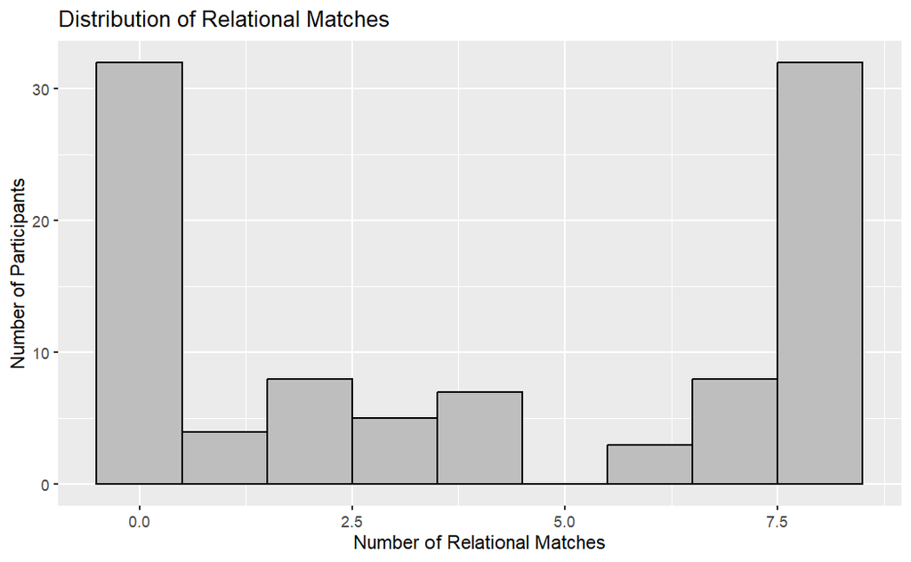

2. The histogram shows that participants generally tend to choose either relational matches or object matches across all trials. This is derived from the fact that an overwhelming majority of participants are at both extremes of the histogram.

| qualtrics_id | trial 1 | trial 2 | trial 3 | trial 4 | trial 5 | trial 6 | trial 7 | trial 8 |
| --- | --- | --- | --- | --- | --- | --- | --- | --- |
| R_2dlRKzx851f1Yd9 | Obj | Obj | Obj | Obj | Obj | Obj | Obj | Obj |
| R_Qb1tzaskoeU0kLf | Obj | Obj | Obj | Obj | Obj | Obj | Obj | Obj |
| R_8AGSWBQpPasvjmp | Rel | Rel | Rel | Rel | Rel | Rel | Rel | Obj |
| R_1Tv8RlXGXRDH6BX | Obj | Obj | Obj | Obj | Obj | Obj | Obj | Obj |
| R_3p3Glk1o4y2BcRe | Obj | Obj | Obj | Obj | Obj | Obj | Obj | Rel |
| R_NVYrJklfFqRVOnv | Obj | Obj | Obj | Obj | Obj | Obj | Obj | Obj |
| R_u4J8rwDfOmm4gYV | Obj | Rel | Obj | Rel | Rel | Rel | Obj | Obj |
| R_1lnLF0rQ3biXSbK | Obj | Rel | Rel | Rel | Rel | Rel | Rel | Rel |
| R_3Mm44PUN5bz3OjI | Obj | Obj | Obj | Obj | Obj | Obj | Obj | Obj |
| R_1F9e3CRe4Tb8JhE | Rel | Rel | Obj | Obj | Obj | Obj | Obj | Obj |

[output cut: 89 more lines]

Show My Work

This code chuck did work, just not in the way that I intended it to. After removing the unnecessary columns, I wanted to reorder the columns so that it would start at trial 1 and increment to trial 8. In the corrected code chunk, I added a prefix of “trials” so that I would be more specific. I then realized that I am still a little unfamiliar with the syntax for certain functions, thus forgetting to put the column names in quotations.

# Week 4 Assignment

| qualtrics_id | sub_type | item_number | rev_scoring | response | scored_response |
| --- | --- | --- | --- | --- | --- |
| R_1lnLF0rQ3biXSbK | RE | 1 | neg | 2 | 4 |
| R_1lnLF0rQ3biXSbK | RA | 1 | neg | 4 | 2 |
| R_1lnLF0rQ3biXSbK | RE | 2 | NA | 3 | 3 |
| R_1lnLF0rQ3biXSbK | RA | 2 | neg | 3 | 3 |
| R_1lnLF0rQ3biXSbK | RE | 3 | neg | 2 | 4 |
| R_1lnLF0rQ3biXSbK | RE | 4 | NA | 2 | 2 |

| qualtrics_id | sub_type | item_number | rev_scoring | response | scored_response |
| --- | --- | --- | --- | --- | --- |
| R_1lnLF0rQ3biXSbK | RE | 1 | neg | 2 | 4 |
| R_1lnLF0rQ3biXSbK | RA | 1 | neg | 4 | 2 |
| R_1lnLF0rQ3biXSbK | RE | 2 | NA | 3 | 3 |
| R_1lnLF0rQ3biXSbK | RA | 2 | neg | 3 | 3 |
| R_1lnLF0rQ3biXSbK | RE | 3 | neg | 2 | 4 |
| R_1lnLF0rQ3biXSbK | RE | 4 | NA | 2 | 2 |
| R_1lnLF0rQ3biXSbK | RE | 5 | neg | 2 | 4 |
| R_1lnLF0rQ3biXSbK | RA | 3 | neg | 2 | 4 |
| R_1lnLF0rQ3biXSbK | RA | 4 | neg | 2 | 4 |
| R_1lnLF0rQ3biXSbK | RE | 6 | NA | 2 | 2 |

[output cut: 990 more lines]

1. It is likely that the columns for “response” and “scored_response” have different column types because they contain different data. The column type for response is because it is likely that the response can be more than just a number, resulting in the whole column being treated as a non-numeric character. It is likely that the column type for response is double because the column only contains numeric values.

| qualtrics_id | sub_type | item_number | rev_scoring | response | scored_response |
| --- | --- | --- | --- | --- | --- |
| R_1lnLF0rQ3biXSbK | RE | 1 | neg | 2 | 4 |
| R_1lnLF0rQ3biXSbK | RA | 1 | neg | 4 | 2 |
| R_1lnLF0rQ3biXSbK | RE | 2 | NA | 3 | 3 |
| R_1lnLF0rQ3biXSbK | RA | 2 | neg | 3 | 3 |
| R_1lnLF0rQ3biXSbK | RE | 3 | neg | 2 | 4 |
| R_1lnLF0rQ3biXSbK | RE | 4 | NA | 2 | 2 |
| R_1lnLF0rQ3biXSbK | RE | 5 | neg | 2 | 4 |
| R_1lnLF0rQ3biXSbK | RA | 3 | neg | 2 | 4 |
| R_1lnLF0rQ3biXSbK | RA | 4 | neg | 2 | 4 |
| R_1lnLF0rQ3biXSbK | RE | 6 | NA | 2 | 2 |

[output cut: 990 more lines]

| qualtrics_id | sub_type | item_number | rev_scoring | response | scored_response | new_scored_response |
| --- | --- | --- | --- | --- | --- | --- |
| R_1lnLF0rQ3biXSbK | RE | 1 | neg | 2 | 4 | 4 |
| R_1lnLF0rQ3biXSbK | RA | 1 | neg | 4 | 2 | 2 |
| R_1lnLF0rQ3biXSbK | RE | 2 | NA | 3 | 3 | 3 |
| R_1lnLF0rQ3biXSbK | RA | 2 | neg | 3 | 3 | 3 |
| R_1lnLF0rQ3biXSbK | RE | 3 | neg | 2 | 4 | 4 |
| R_1lnLF0rQ3biXSbK | RE | 4 | NA | 2 | 2 | 2 |
| R_1lnLF0rQ3biXSbK | RE | 5 | neg | 2 | 4 | 4 |
| R_1lnLF0rQ3biXSbK | RA | 3 | neg | 2 | 4 | 4 |
| R_1lnLF0rQ3biXSbK | RA | 4 | neg | 2 | 4 | 4 |
| R_1lnLF0rQ3biXSbK | RE | 6 | NA | 2 | 2 | 2 |

[output cut: 990 more lines]

| resp_check |
| --- |
| TRUE |
| NA |

# Week 5 Assignment

| sub_type |
| --- |
| RE |
| RA |
| EE |
| EA |

| qualtrics_id | sub_type | total_score |
| --- | --- | --- |
| R_0SrX3uRtXaupbhv | EA | 31 |
| R_0SrX3uRtXaupbhv | EE | 25 |
| R_0SrX3uRtXaupbhv | RA | 38 |
| R_0SrX3uRtXaupbhv | RE | 37 |
| R_0V8O8mrLiHO3Ghj | EA | 22 |
| R_0V8O8mrLiHO3Ghj | EE | 22 |
| R_0V8O8mrLiHO3Ghj | RA | 42 |
| R_0V8O8mrLiHO3Ghj | RE | 42 |
| R_1BW5H5J1jQFEpuk | EA | 32 |
| R_1BW5H5J1jQFEpuk | EE | 25 |

[output cut: 390 more lines]

| qualtrics_id | sub_type | total_score |
| --- | --- | --- |
| R_1F9e3CRe4Tb8JhE | RE | NA |
| R_1lnLF0rQ3biXSbK | RA | NA |
| R_25FgHNiNx7jLHy1 | EA | NA |
| R_2c60t6KOIDTWPQb | RE | NA |
| R_3NV67BeT8swOBOf | RA | NA |
| R_3frS5bkaT1hzbPh | EA | NA |
| R_3frS5bkaT1hzbPh | EE | NA |
| R_3frS5bkaT1hzbPh | RA | NA |
| R_OxLEJkniZlsCYut | EE | NA |
| R_STy7opVLSgSa2uB | EE | NA |

[output cut: 3 more lines]

1b. Yes, there are scores that are NA.

| qualtrics_id | sub_type | total_score |
| --- | --- | --- |
| R_0SrX3uRtXaupbhv | EA | 31 |
| R_0SrX3uRtXaupbhv | EE | 25 |
| R_0SrX3uRtXaupbhv | RA | 38 |
| R_0SrX3uRtXaupbhv | RE | 37 |
| R_0V8O8mrLiHO3Ghj | EA | 22 |
| R_0V8O8mrLiHO3Ghj | EE | 22 |
| R_0V8O8mrLiHO3Ghj | RA | 42 |
| R_0V8O8mrLiHO3Ghj | RE | 42 |
| R_1BW5H5J1jQFEpuk | EA | 32 |
| R_1BW5H5J1jQFEpuk | EE | 25 |

[output cut: 390 more lines]

| qualtrics_id | sub_type | total_score |
| --- | --- | --- |

| qualtrics_id | sub_type | total_score | relational_matches |
| --- | --- | --- | --- |
| R_0SrX3uRtXaupbhv | EA | 31 | 0 |
| R_0SrX3uRtXaupbhv | EE | 25 | 0 |
| R_0SrX3uRtXaupbhv | RA | 38 | 0 |
| R_0SrX3uRtXaupbhv | RE | 37 | 0 |
| R_0V8O8mrLiHO3Ghj | EA | 22 | 8 |
| R_0V8O8mrLiHO3Ghj | EE | 22 | 8 |
| R_0V8O8mrLiHO3Ghj | RA | 42 | 8 |
| R_0V8O8mrLiHO3Ghj | RE | 42 | 8 |
| R_1BW5H5J1jQFEpuk | EA | 32 | 8 |
| R_1BW5H5J1jQFEpuk | EE | 25 | 8 |

[output cut: 386 more lines]

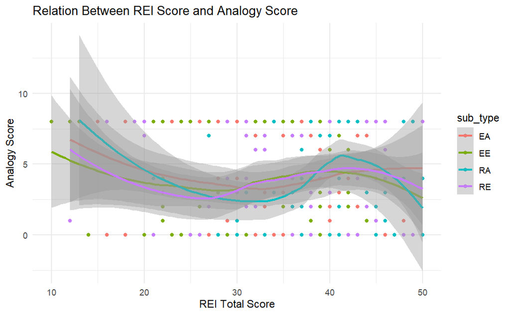

3. There is some variability in the different best fit lines per sub-type. However,it seems that there is little to no correlation between the total scoring of the REI sub-types and the number of relational matches made.

# Week 6 Assignment

1. loading data file

| SubID | condition | discreteness | regularity | integration | major_color | rt_toolong | rt_tooshort | rt_exclu | shape | details | trial_index | block | left_stim | right_stim | left_path | right_path | rt | response | correct |
| --- | --- | --- | --- | --- | --- | --- | --- | --- | --- | --- | --- | --- | --- | --- | --- | --- | --- | --- | --- |
| R_2dlRKzx851f1Yd9 | dots_EqSizeSep | discrete | irregular | separated | blue | 0 | 0 | 0 | dots | EqSizeSep | 5 | 0 | 11_3 | 2_18 | StimFiles/dots_EqSizeSep_blue_11_3.jpeg | StimFiles/dots_EqSizeSep_blue_2_18.jpeg | 3952 | arrowleft | TRUE |
| R_2dlRKzx851f1Yd9 | dots_EqSizeSep | discrete | irregular | separated | blue | 0 | 0 | 0 | dots | EqSizeSep | 8 | 0 | 2_38 | 46_4 | StimFiles/dots_EqSizeSep_blue_2_38.jpeg | StimFiles/dots_EqSizeSep_blue_46_4.jpeg | 2708 | arrowright | TRUE |
| R_2dlRKzx851f1Yd9 | dots_EqSizeSep | discrete | irregular | separated | blue | 0 | 0 | 0 | dots | EqSizeSep | 11 | 0 | 3_11 | 18_2 | StimFiles/dots_EqSizeSep_blue_3_11.jpeg | StimFiles/dots_EqSizeSep_blue_18_2.jpeg | 2572 | arrowright | TRUE |
| R_2dlRKzx851f1Yd9 | dots_EqSizeSep | discrete | irregular | separated | blue | 0 | 0 | 0 | dots | EqSizeSep | 14 | 0 | 38_2 | 3_47 | StimFiles/dots_EqSizeSep_blue_38_2.jpeg | StimFiles/dots_EqSizeSep_blue_3_47.jpeg | 2721 | arrowleft | TRUE |
| R_2dlRKzx851f1Yd9 | dots_EqSizeSep | discrete | irregular | separated | blue | 0 | 0 | 0 | dots | EqSizeSep | 17 | 0 | 7_13 | 12_28 | StimFiles/dots_EqSizeSep_blue_7_13.jpeg | StimFiles/dots_EqSizeSep_blue_12_28.jpeg | 2810 | arrowright | FALSE |
| R_2dlRKzx851f1Yd9 | dots_EqSizeSep | discrete | irregular | separated | blue | 0 | 0 | 0 | dots | EqSizeSep | 20 | 0 | 6_9 | 9_36 | StimFiles/dots_EqSizeSep_blue_6_9.jpeg | StimFiles/dots_EqSizeSep_blue_9_36.jpeg | 2395 | arrowright | FALSE |
| R_2dlRKzx851f1Yd9 | dots_EqSizeSep | discrete | irregular | separated | blue | 0 | 0 | 0 | dots | EqSizeSep | 23 | 0 | 32_10 | 35_18 | StimFiles/dots_EqSizeSep_blue_32_10.jpeg | StimFiles/dots_EqSizeSep_blue_35_18.jpeg | 2599 | arrowright | FALSE |
| R_2dlRKzx851f1Yd9 | dots_EqSizeSep | discrete | irregular | separated | blue | 0 | 0 | 0 | dots | EqSizeSep | 26 | 0 | 16_26 | 17_30 | StimFiles/dots_EqSizeSep_blue_16_26.jpeg | StimFiles/dots_EqSizeSep_blue_17_30.jpeg | 2475 | arrowright | FALSE |
| R_2dlRKzx851f1Yd9 | dots_EqSizeSep | discrete | irregular | separated | blue | 0 | 0 | 0 | dots | EqSizeSep | 30 | 1 | 32_16 | 30_9 | StimFiles/dots_EqSizeSep_blue_32_16.jpeg | StimFiles/dots_EqSizeSep_blue_30_9.jpeg | 2673 | arrowleft | FALSE |
| R_2dlRKzx851f1Yd9 | dots_EqSizeSep | discrete | irregular | separated | blue | 0 | 0 | 0 | dots | EqSizeSep | 32 | 1 | 17_30 | 16_26 | StimFiles/dots_EqSizeSep_blue_17_30.jpeg | StimFiles/dots_EqSizeSep_blue_16_26.jpeg | 2694 | arrowright | TRUE |

[output cut: 990 more lines]

2a. create a vector

```
[1] "dots_EqSizeSep"  "dots_EqSizeRand" "blob_shifted"    "blob_stacked"
```

2b. calculate mean

```
[1] 889.8202 879.6184 915.1974 866.0546
```

logical explanation:

create a vector for the mean reaction times. in order to find the mean of each condition, i first need to filter out all of the valid trials (where rt_exclu == 0). then i can loop per condition and check where the condition in the valid trials matches one of the conditions in our conditions vector. after that i need to calculate the mean for all of the reactions of that specific condition and put that in our mean reaction time vector.

| condition | mean_rt | overall_accuracy |
| --- | --- | --- |
| blob_shifted | 915.1974 | 0.6243687 |
| blob_stacked | 866.0546 | 0.7067551 |
| dots_EqSizeRand | 879.6184 | 0.6873840 |
| dots_EqSizeSep | 889.8202 | 0.6176562 |

| condition | mean_rt | overall_accuracy |
| --- | --- | --- |
| blob_shifted | 915.1974 | 0.6243687 |
| blob_stacked | 866.0546 | 0.7067551 |
| dots_EqSizeRand | 879.6184 | 0.6873840 |
| dots_EqSizeSep | 889.8202 | 0.6176562 |

# Week 7 Assignment

| SubID | condition | discreteness | regularity | integration | major_color | rt_toolong | rt_tooshort | rt_exclu | shape | details | trial_index | block | left_stim | right_stim | left_path | right_path | rt | response | correct |
| --- | --- | --- | --- | --- | --- | --- | --- | --- | --- | --- | --- | --- | --- | --- | --- | --- | --- | --- | --- |
| R_2dlRKzx851f1Yd9 | dots_EqSizeSep | discrete | irregular | separated | blue | 0 | 0 | 0 | dots | EqSizeSep | 5 | 0 | 11_3 | 2_18 | StimFiles/dots_EqSizeSep_blue_11_3.jpeg | StimFiles/dots_EqSizeSep_blue_2_18.jpeg | 3952 | arrowleft | TRUE |
| R_2dlRKzx851f1Yd9 | dots_EqSizeSep | discrete | irregular | separated | blue | 0 | 0 | 0 | dots | EqSizeSep | 8 | 0 | 2_38 | 46_4 | StimFiles/dots_EqSizeSep_blue_2_38.jpeg | StimFiles/dots_EqSizeSep_blue_46_4.jpeg | 2708 | arrowright | TRUE |
| R_2dlRKzx851f1Yd9 | dots_EqSizeSep | discrete | irregular | separated | blue | 0 | 0 | 0 | dots | EqSizeSep | 11 | 0 | 3_11 | 18_2 | StimFiles/dots_EqSizeSep_blue_3_11.jpeg | StimFiles/dots_EqSizeSep_blue_18_2.jpeg | 2572 | arrowright | TRUE |
| R_2dlRKzx851f1Yd9 | dots_EqSizeSep | discrete | irregular | separated | blue | 0 | 0 | 0 | dots | EqSizeSep | 14 | 0 | 38_2 | 3_47 | StimFiles/dots_EqSizeSep_blue_38_2.jpeg | StimFiles/dots_EqSizeSep_blue_3_47.jpeg | 2721 | arrowleft | TRUE |
| R_2dlRKzx851f1Yd9 | dots_EqSizeSep | discrete | irregular | separated | blue | 0 | 0 | 0 | dots | EqSizeSep | 17 | 0 | 7_13 | 12_28 | StimFiles/dots_EqSizeSep_blue_7_13.jpeg | StimFiles/dots_EqSizeSep_blue_12_28.jpeg | 2810 | arrowright | FALSE |
| R_2dlRKzx851f1Yd9 | dots_EqSizeSep | discrete | irregular | separated | blue | 0 | 0 | 0 | dots | EqSizeSep | 20 | 0 | 6_9 | 9_36 | StimFiles/dots_EqSizeSep_blue_6_9.jpeg | StimFiles/dots_EqSizeSep_blue_9_36.jpeg | 2395 | arrowright | FALSE |
| R_2dlRKzx851f1Yd9 | dots_EqSizeSep | discrete | irregular | separated | blue | 0 | 0 | 0 | dots | EqSizeSep | 23 | 0 | 32_10 | 35_18 | StimFiles/dots_EqSizeSep_blue_32_10.jpeg | StimFiles/dots_EqSizeSep_blue_35_18.jpeg | 2599 | arrowright | FALSE |
| R_2dlRKzx851f1Yd9 | dots_EqSizeSep | discrete | irregular | separated | blue | 0 | 0 | 0 | dots | EqSizeSep | 26 | 0 | 16_26 | 17_30 | StimFiles/dots_EqSizeSep_blue_16_26.jpeg | StimFiles/dots_EqSizeSep_blue_17_30.jpeg | 2475 | arrowright | FALSE |
| R_2dlRKzx851f1Yd9 | dots_EqSizeSep | discrete | irregular | separated | blue | 0 | 0 | 0 | dots | EqSizeSep | 30 | 1 | 32_16 | 30_9 | StimFiles/dots_EqSizeSep_blue_32_16.jpeg | StimFiles/dots_EqSizeSep_blue_30_9.jpeg | 2673 | arrowleft | FALSE |
| R_2dlRKzx851f1Yd9 | dots_EqSizeSep | discrete | irregular | separated | blue | 0 | 0 | 0 | dots | EqSizeSep | 32 | 1 | 17_30 | 16_26 | StimFiles/dots_EqSizeSep_blue_17_30.jpeg | StimFiles/dots_EqSizeSep_blue_16_26.jpeg | 2694 | arrowright | TRUE |

[output cut: 990 more lines]

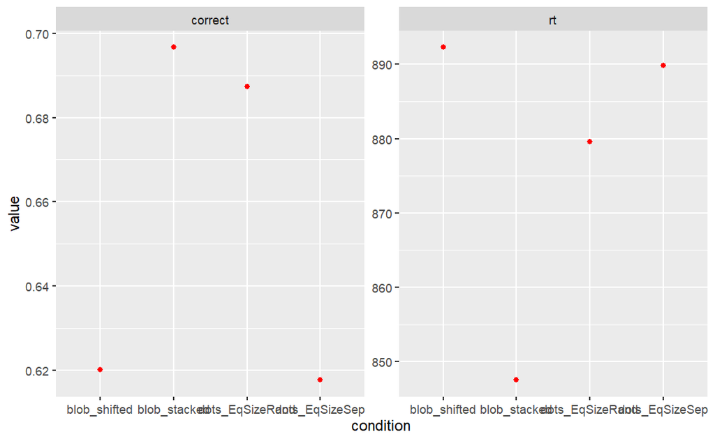

1a. From the plot, I assume that a higher proportion of correct scores results from a better reaction time or vice versa. Blob_stacked and dots_EqSizeRand have higher accuracy and a faster reaction time, while blob_shifted and dots_EqSizeSep are lower in accuracy with a slower reaction time.

1b. The first thing that I noticed were the values in the axes of the graphs. Typically, graphs with great variability tend to have large ranges that contribute to conclusions about relationships. For example, I expected to see something along the lines of a higher accuracy results in a slower reaction time. More specifically, the blob_stacked column stood out as it had the highest accuracy but the fastest reaction time.

1c. Some information that I find difficult to see is a clear relationship between the accuracy of the conditions and the mean reaction time. The conclusion I came to in 1a is a pure assumption from looking at it, but I feel as though there are ways to visualize the information better. Further descriptive information of the graph and its axes could also be helpful. There is no title to describe what data we are looking at, and the y-axis in particular lacks information about what the values for each graph are.

2a. summarize the data set

| SubID | condition | prop_corr |
| --- | --- | --- |
| R_0SrX3uRtXaupbhv | dots_EqSizeRand | 0.4696970 |
| R_0SrX3uRtXaupbhv | dots_EqSizeSep | 0.6666667 |
| R_0V8O8mrLiHO3Ghj | blob_shifted | 0.4696970 |
| R_0V8O8mrLiHO3Ghj | blob_stacked | 0.7045455 |
| R_1BW5H5J1jQFEpuk | blob_shifted | 0.5303030 |
| R_1BW5H5J1jQFEpuk | blob_stacked | 0.7045455 |
| R_1E0SHQwiV6CXRoo | blob_shifted | 0.5833333 |
| R_1E0SHQwiV6CXRoo | blob_stacked | 0.7121212 |
| R_1F9e3CRe4Tb8JhE | blob_shifted | 0.5454545 |
| R_1F9e3CRe4Tb8JhE | blob_stacked | 0.6136364 |

[output cut: 188 more lines]

2b. make the plot

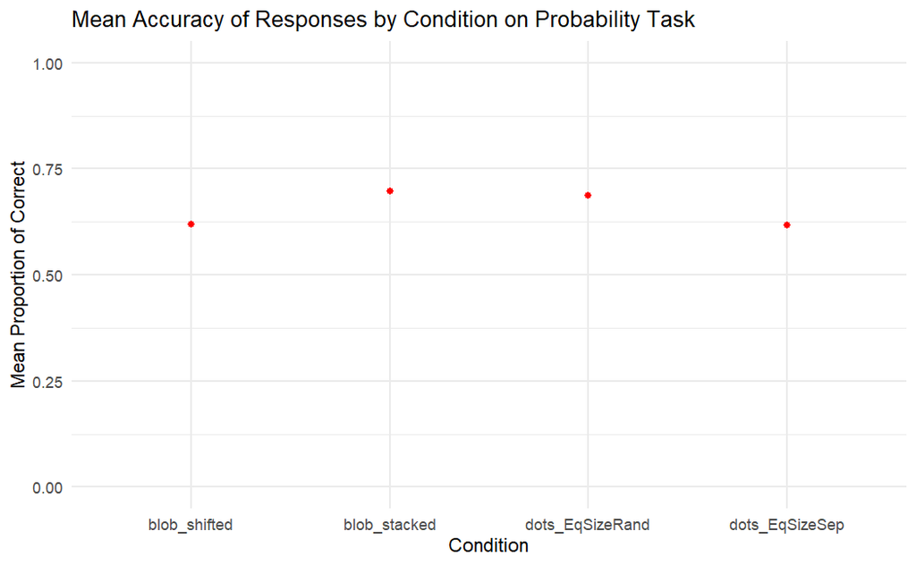

2c. To make the graph less misleading, I added a descriptive title and y-axis so the reader knows the graph that they are looking at and what information is being displayed on it. I also changed the scale so that it better shows that the y-axis is a proportion.

3a. add distributional info

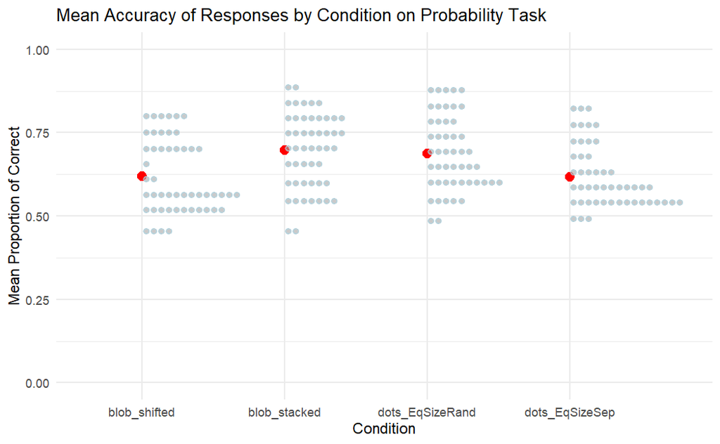

3b. What does this graph tell us: From my understanding, the dots represent individual cases of proportion correct for the different SubID’s. Thus, it allows us to see the variability across the data set and where responses were more concentrated. Overall, it gives us more information about why the mean proportion of correct for each condition is the way it is.

Aesthetics: As seen above, I changed the scale of the y-axis, added a descriptive title and y-axis title, set the theme to minimal. I made the actual mean points larger so that they would stand out more in comparison to the dots. For the geom_dotsintervals, I changed the color to light blue, reduced their size, and lessened their opacity so it didn’t overtake the importance of the mean.

# Week 8 Assignment

| SubID | condition | rt | correct |
| --- | --- | --- | --- |
| R_0SrX3uRtXaupbhv | dots_EqSizeRand | 1029.9470 | 0.4696970 |
| R_0SrX3uRtXaupbhv | dots_EqSizeSep | 985.5682 | 0.6666667 |
| R_0V8O8mrLiHO3Ghj | blob_shifted | 742.1742 | 0.4696970 |
| R_0V8O8mrLiHO3Ghj | blob_stacked | 919.9242 | 0.7045455 |
| R_1BW5H5J1jQFEpuk | blob_shifted | 824.1667 | 0.5303030 |
| R_1BW5H5J1jQFEpuk | blob_stacked | 875.0303 | 0.7045455 |
| R_1E0SHQwiV6CXRoo | blob_shifted | 742.5530 | 0.5833333 |
| R_1E0SHQwiV6CXRoo | blob_stacked | 748.1364 | 0.7121212 |
| R_1F9e3CRe4Tb8JhE | blob_shifted | 672.1364 | 0.5454545 |
| R_1F9e3CRe4Tb8JhE | blob_stacked | 604.1364 | 0.6136364 |

[output cut: 188 more lines]

3a. colors

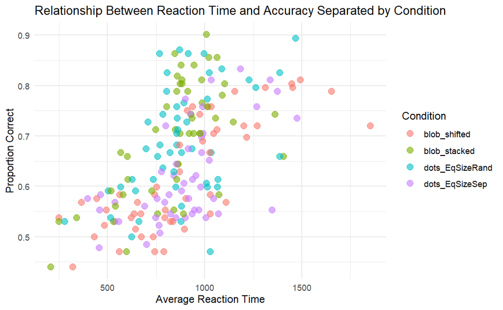

3b. facets in separate plots

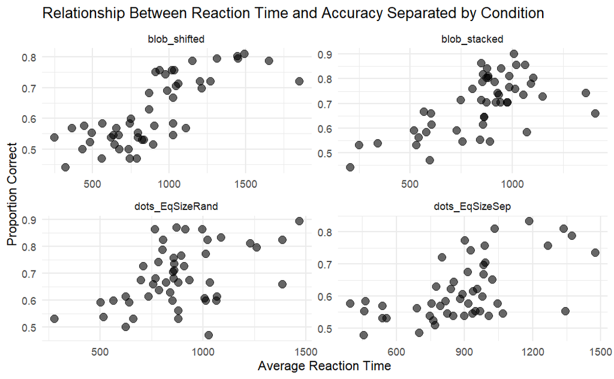